**City College of San Francisco**

MATH 108 - Foundations of Data Science

# Lecture 13: Conditionals and Iteration

Associated Textbook Sections: [9.0, 9.1, 9.2, 9.3](https://inferentialthinking.com/chapters/09/Randomness.html)

## Set Up the Notebook

```python
from datascience import *
import numpy as np
%matplotlib inline
import matplotlib.pyplot as plots
plots.style.use('fivethirtyeight')
#import warnings
#warnings.simplefilter(action='ignore',category=np.VisibleDeprecationWarning)
```

## Comparison and Booleans

### Comparison Operators

- Assignments Statements:
  - `x = 6`
  - `height = x * 12`
- Comparison Expressions:
  - `x > 1`
  - `x < y`
  - `y >= 3`
  - `x == y`
  - `x != y`
  - `2 < x < 5`
- The result of a comparison expression is a `bool` value (`True` or `False`)

### Aggregating Comparisons

- Summing an array or list of `bool` values will count the `True` values only.
- The following produce an output of `2`:
  - `1 + 0 + 1`
  - `True + False + True`
  - `sum([1, 0, 1])`
  - `sum([True, False, True])`

### Demo: Comparison

Demonstrate using the comparison operators.

```python
3 > 1
```

```
True
```

```python
type(3 > 1)
```

```
bool
```

```python
True
```

```
True
```

```python
true
```

```
---------------------------------------------------------------------------
NameError                                 Traceback (most recent call last)
Input In [5], in <cell line: 1>()
----> 1 true

NameError: name 'true' is not defined
```

```python
3 = 3
```

```
  Input In [6]
    3 = 3
    ^
SyntaxError: cannot assign to literal here. Maybe you meant '==' instead of '='?
```

```python
3 == 3
```

```
True
```

```python
3 == 3.0
```

```
True
```

```python
2 != 10
```

```
True
```

```python
make_array(1, 2, 3) == make_array(2, 1, 3)
```

```
array([False, False,  True], dtype=bool)
```

```python
x = 14
y = 3
```

```python
x < y
```

```
False
```

```python
11 < x < 15
```

```
True
```

Introduce `and`, `or`, `not`.

```python
11 < x and x < 15
```

```
True
```

```python
11 < x and x < 14 # both need to be true
```

```
False
```

```python
11 < x or x < 14 # at least one comparison must be true, to get True
```

```
True
```

```python
not x < 14 # not gives the opposite truth value!
```

```
True
```

### Demo: Comparisons with Arrays

Demonstrate how comparisons work with arrays.

```python
pets = make_array('cat', 'dog', 'dog', 'cat', 'bunny', 'lizard')
pets
```

```
array(['cat', 'dog', 'dog', 'cat', 'bunny', 'lizard'],
      dtype='<U6')
```

```python
pets == 'lizard'
```

```
array([False, False, False, False, False,  True], dtype=bool)
```

```python
sum(pets == 'lizard')
```

```
1
```

```python
len(pets == 'lizard')
```

```
6
```

```python
len(pets)
```

```
6
```

```python
sum(pets == 'lizard') / len(pets) #proportion of lizard responses
```

```
0.16666666666666666
```

```python
an_array = np.arange(20, 57, 0.5)
an_array
```

```
array([ 20. ,  20.5,  21. ,  21.5,  22. ,  22.5,  23. ,  23.5,  24. ,
        24.5,  25. ,  25.5,  26. ,  26.5,  27. ,  27.5,  28. ,  28.5,
        29. ,  29.5,  30. ,  30.5,  31. ,  31.5,  32. ,  32.5,  33. ,
        33.5,  34. ,  34.5,  35. ,  35.5,  36. ,  36.5,  37. ,  37.5,
        38. ,  38.5,  39. ,  39.5,  40. ,  40.5,  41. ,  41.5,  42. ,
        42.5,  43. ,  43.5,  44. ,  44.5,  45. ,  45.5,  46. ,  46.5,
        47. ,  47.5,  48. ,  48.5,  49. ,  49.5,  50. ,  50.5,  51. ,
        51.5,  52. ,  52.5,  53. ,  53.5,  54. ,  54.5,  55. ,  55.5,
        56. ,  56.5])
```

```python
sum(an_array > 21)
```

```
71
```

```python
True + False
```

```
1
```

```python
an_array > 21
```

```
array([False, False, False,  True,  True,  True,  True,  True,  True,
        True,  True,  True,  True,  True,  True,  True,  True,  True,
        True,  True,  True,  True,  True,  True,  True,  True,  True,
        True,  True,  True,  True,  True,  True,  True,  True,  True,
        True,  True,  True,  True,  True,  True,  True,  True,  True,
        True,  True,  True,  True,  True,  True,  True,  True,  True,
        True,  True,  True,  True,  True,  True,  True,  True,  True,
        True,  True,  True,  True,  True,  True,  True,  True,  True,
        True,  True], dtype=bool)
```

```python
not an_array > 21 #:(
```

```
---------------------------------------------------------------------------
ValueError                                Traceback (most recent call last)
Input In [34], in <cell line: 1>()
----> 1 not an_array > 21

ValueError: The truth value of an array with more than one element is ambiguous. Use a.any() or a.all()
```

```python
sum(an_array < 21)
```

```
2
```

```python
sum(an_array <= 21) # The opposite of > is <=, not <.
```

```
3
```

## Control Statements

### Control Statements

These statements control the sequence of computations that are performed in a program

- The keywords `if` and `for` begin control statements
- The purpose of `if` is to choose different code segments based on their arguments.

### Demo: Simulation

Consider the following game where each of 2 players rolls a die.

- The player with the smaller value pays the other player one dollar.
- If there is a tie, then no one pays anything.

Find a way to simulate one round of the game where each player rolls a die. It might help to think from the perspective of one of the players.

```python
# Work in progress
def one_round(player1, player2):
    if player1 > player2: # You need a : with if!
        return 1 # trapped by the conditional statement. It needs to be True, to run this code.
```

```python
one_round(4, 3)
```

```
1
```

```python
one_round(2, 6) # one_round didn't specify what to do for this case!
```

```python
# Work in progress
def one_round(player1, player2):
    if player1 > player2:
        return 1
    elif player1 < player2: #elif is like else, if ...
        return -1
```

```python
one_round(4, 3)
```

```
1
```

```python
one_round(2, 6)
```

```
-1
```

```python
one_round(2, 2)
```

```python
def one_round(player1, player2):
    if player1 > player2:
        return 1
    elif player1 < player2:
        return -1
    else:
        return 0
```

```python
one_round(2, 2)
```

```
0
```

## Random Selection

### Random Selection

The command

`np.random.choice(some_array, sample_size)`

creates an array by selecting a number (`sample_size`) of values uniformly at random with replacement from an array (`some_array`).

### Demo: Random Selection

Demonstrate how to use `np.random.choice`.

```python
mornings = make_array('wake_up', 'sleep in')
```

```python
np.random.choice(mornings)
```

```
'sleep in'
```

```python
np.random.choice(mornings, 7)
```

```
array(['wake_up', 'wake_up', 'wake_up', 'sleep in', 'wake_up', 'sleep in',
       'sleep in'],
      dtype='<U8')
```

```python
my_week = np.random.choice(mornings, 7)
my_week
```

```
array(['wake_up', 'wake_up', 'sleep in', 'sleep in', 'sleep in', 'wake_up',
       'wake_up'],
      dtype='<U8')
```

```python
my_week
```

```
array(['wake_up', 'wake_up', 'sleep in', 'sleep in', 'sleep in', 'wake_up',
       'wake_up'],
      dtype='<U8')
```

```python
sum(my_week=='wake_up')
```

```
4
```

Create an array that represents the faces of a single six-sided die.

```python
die_faces = np.arange(1, 7)
die_faces
```

```
array([1, 2, 3, 4, 5, 6])
```

```python
np.random.choice(die_faces)
```

```
1
```

Create a function that simulates one round of the game described earlier by randomly generating the rolls.

```python
def simulate_one_round():
    die_faces = np.arange(1, 7)
    player1 = np.random.choice(die_faces)
    player2 = np.random.choice(die_faces)
    return one_round(player1, player2)
```

```python
simulate_one_round()
```

```
-1
```

## Appending Arrays

### A Longer Array

- `np.append(array_1, value)`
  - new array with value appended to `array_1`
  - `value` has to be of the same type as elements of `array_1`
- `np.append(array_1, array_2)`
  - new array with `array_2` appended to `array_1`
  - `array_2` elements must have the same type as `array_1` elements

### Demo: Appending Arrays

Demonstrate how to append values to an array.

```python
first = np.arange(6)
second = np.arange(10, 20)
```

```python
first
```

```
array([0, 1, 2, 3, 4, 5])
```

```python
np.append(first, 6) # creates a NEW array!
```

```
array([0, 1, 2, 3, 4, 5, 6])
```

```python
first = np.append(first, 6)
first
```

```
array([0, 1, 2, 3, 4, 5, 6])
```

```python
first = np.append(first, 6)
first
```

```
array([0, 1, 2, 3, 4, 5, 6, 6])
```

```python
first
```

```
array([0, 1, 2, 3, 4, 5, 6, 6])
```

```python
second
```

```
array([10, 11, 12, 13, 14, 15, 16, 17, 18, 19])
```

```python
np.append(first, second)
```

```
array([ 0,  1,  2,  3,  4,  5,  6,  6, 10, 11, 12, 13, 14, 15, 16, 17, 18,
       19])
```

### Demo: Repeated Betting

Store the results of the simulated game in an array for each player. First, create an empty array.

```python
player1_results = make_array() # an empty array
player1_results
```

```
array([], dtype=float64)
```

```python
np.append(player1_results, simulate_one_round())
```

```
array([ 0.])
```

```python
np.append(player1_results, simulate_one_round) # needs to be a value, so use ()s
```

```
array([<function simulate_one_round at 0x7f37249f20e0>], dtype=object)
```

```python
player1_results = np.append(player1_results, simulate_one_round())
player1_results
```

```
array([ 1., -1.,  1., -1., -1.])
```

## Iteration

### `for` Statements

- `for` is a keyword that begins a control statement
- The purpose of `for` is to perform a computation for every element in a list or array

### Demo: `for` Statements

Demonstrate how `for` statements work.

```python
pets
```

```
array(['cat', 'dog', 'dog', 'cat', 'bunny', 'lizard'],
      dtype='<U6')
```

```python
for pet in pets:
    print('I love my ' + pet)
```

```
I love my cat
I love my dog
I love my dog
I love my cat
I love my bunny
I love my lizard
```

```python
for __ in pets: #
    print('hi')
```

```
hi
hi
hi
hi
hi
hi
```

Simulate and the store results of 10,000 iterations of the game described earlier.

```python
player1_outcomes = make_array()
player1_outcomes
```

```
array([], dtype=float64)
```

```python
for __ in np.arange(10000):
    player1_outcomes = np.append(player1_outcomes, simulate_one_round())
```

```python
player1_outcomes
```

```
array([-1.,  1.,  0., ...,  1.,  0.,  0.])
```

```python
len(player1_outcomes)
```

```
10000
```

Create a table with the results of the game and visualize the results for Player 1.

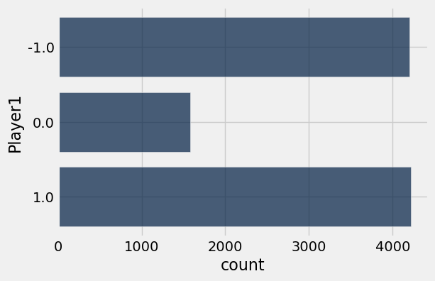

```python
Table().with_column('Player1', player1_outcomes).group('Player1').barh('Player1')
```

### Demo: Simulating Heads in 100 Coin Tosses

Create a fair coin and develop the components to simulate flipping the coin 100 times. Make sure to keep track of the results where the simulation is repeated 10,000 times.

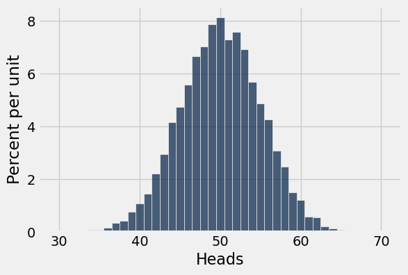

```python
coin = make_array('heads', 'tails')

# Simulate one outcome
def num_heads():
    return sum(np.random.choice(coin, 100) == 'heads')

# Decide how many times you want to repeat the experiment
repetitions = 10000

# Simulate that many outcomes
outcomes = make_array()
for i in np.arange(repetitions):
    outcomes = np.append(outcomes, num_heads())

# Visualize the results
heads = Table().with_column('Heads', outcomes)
heads.hist(bins = np.arange(29.5, 70.6))
```

## Advanced `where`

### A Closer Look at `where`

The command

`t.where(array_of_bool_values)`

returns a table with only the rows of `t` for which the corresponding `bool` is `True`.

### Demo: Advanced `where`

Demonstrate how to use conditionals with the `where` method.

```python
ages = make_array(16, 22, 18, 15, 19, 15, 16, 21)
age = Table().with_column('Age', ages)
age
```

| Age |
| --- |
| 16 |
| 22 |
| 18 |
| 15 |
| 19 |
| 15 |
| 16 |
| 21 |

```python
age.where('Age', are.above_or_equal_to(18))
```

| Age |
| --- |
| 22 |
| 18 |
| 19 |
| 21 |

```python
voter = ages >= 18
age.where(voter)
```

| Age |
| --- |
| 22 |
| 18 |
| 19 |
| 21 |

```python
is_voter = are.above_or_equal_to(18)
```

```python
age.apply(is_voter, 'Age')
```

```
array([False,  True,  True, False,  True, False, False,  True], dtype=bool)
```

```python
def my_voter_function(x):
    return x >= 18
```

```python
age.where('Age', my_voter_function)
```

| Age |
| --- |
| 22 |
| 18 |
| 19 |
| 21 |